# Python Foundations Project: FoodHub Data Analysis

##### Observations on Overall Delivery Time (Food Preparation Time + Delivery Time):

```python
# Create a column overall_order_time for the total time it took to prepare and deliver the order (food_preparation_time + delivery_time)
df['overall_order_time'] = df['food_preparation_time'] + df['delivery_time']
df['overall_order_time'] = df['overall_order_time'].astype(int)
```

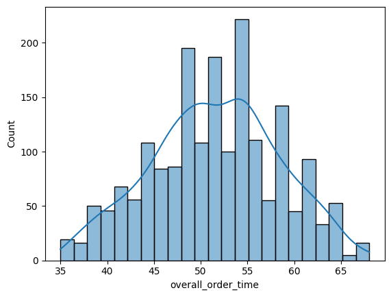

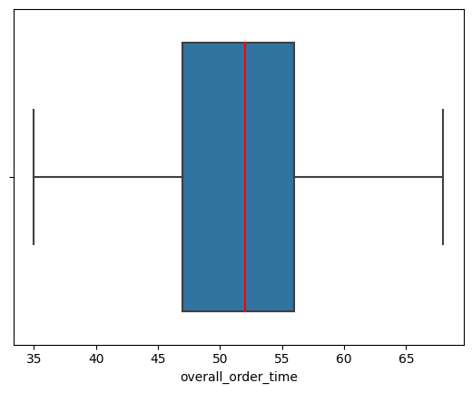

```python
# Display the distribution of overall_order_time
data = df

sns.histplot(data = data, x = 'overall_order_time', kde = True)

plt.show()

sns.boxplot(data = data, x = 'overall_order_time', medianprops = {'color': 'r'})

plt.show()
```

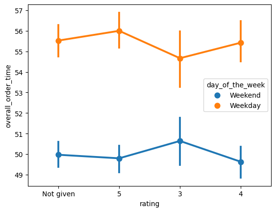

```python
# Display the distribution of overall_order_time for every rating per day_of_the_week
data = df

ax = sns.pointplot(data = data, y = 'overall_order_time', x = 'rating', hue = 'day_of_the_week')

plt.show()
```

**Observations:**

- When columns Food Preparation Time and Delivery Time are summed-up, they seem to follow normal distribution as they represent a sharp peak in the middle.
- These columns are slightly symmetrical.
- There are no outliers present in these columns.

##### Observations on Cuisine Type:

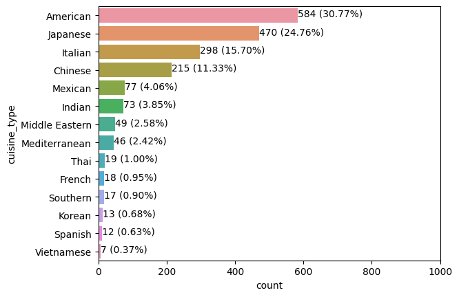

```python
# Display the number of orders per cuisine_type
data = df
order = data['cuisine_type'].value_counts().index

ax = sns.countplot(data = data, y = 'cuisine_type', order = order)

set_bin_label_ycountplot(ax, data, '.0f', '.2f')

plt.xlim(0, 1000)
plt.show()
```

**Observations:**

- About 82% of all the orders are made up of only four cuisines: American, Japanese, Italian and Chinese.
- While the Vietnamese, Spanish, Korean, Southern and French cuisines combined, only received less than 5% of the total orders.

##### Observations on Day of the Week:

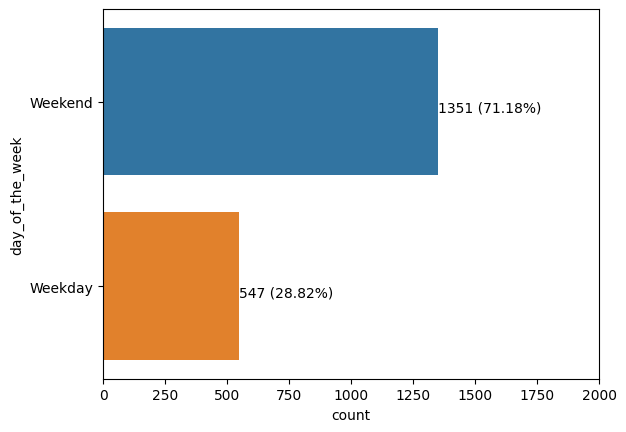

```python
# Display the number of orders per day_of_the_week
data = df
order = data['day_of_the_week'].value_counts().index

ax = sns.countplot(data = data, y = 'day_of_the_week', order = order)

set_bin_label_ycountplot(ax, data, '.0f', '.2f')

plt.xlim(0, 2000)
plt.show()
```

**Observations:**

- Weekends received a total of 1,351 orders (or 71.18%) compared to weekdays that only received 547 (or 28.82%).

##### Observations on Rating:

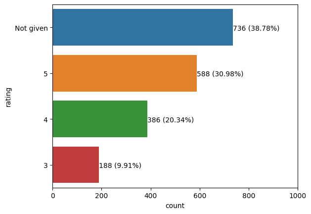

```python
# Display the number of orders per rating
data = df
order = data['rating'].value_counts().index

ax = sns.countplot(data = data, y = 'rating', order = order)

set_bin_label_ycountplot(ax, data, '.0f', '.2f')

plt.xlim(0, 1000)
plt.show()
```

```python
# Create a DataFrame for orders that have been rated
df_wth_rating = df[df['rating'] != 'Not given'].reset_index(drop = True).copy()
df_wth_rating['rating'] = df_wth_rating['rating'].astype(int)

# Create a DataFrame for orders that have not been rated
df_wo_rating = df[df['rating'] == 'Not given'].reset_index(drop = True).copy()
df_wo_rating['rating'] = df_wo_rating['rating'].astype(object)
```

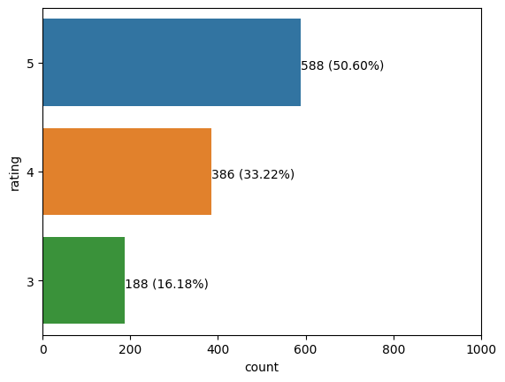

```python
# Display the number of orders per rating (only for orders that have been rated)
data = df_wth_rating
order = data['rating'].value_counts().index

ax = sns.countplot(data = data, y = 'rating', order = order)

set_bin_label_ycountplot(ax, data, '.0f', '.2f')

plt.xlim(0, 1000)
plt.show()
```

**Observations:**

- 736 (or 38.78%) of the orders have not been rated by the customers.
- About half of the customers who rated their orders gave 5 rating which indicates that customers are happy with their orders.

### **Question 7**: Which are the top 5 restaurants in terms of the number of orders received?

```python
# Display the top 5 restaurants with the most orders
top_res_ord = df.groupby(by = 'restaurant_name').size().sort_values(ascending = False).reset_index().rename(columns = {0: 'count'}).head(5)

top_res_ord
```

|  | restaurant_name | count |
| --- | --- | --- |
| 0 | Shake Shack | 219 |
| 1 | The Meatball Shop | 132 |
| 2 | Blue Ribbon Sushi | 119 |
| 3 | Blue Ribbon Fried Chicken | 96 |
| 4 | Parm | 68 |

**Observations:**

- Shake Shack is the most popular restaurant in FoodHub, making 219 (or 11.53%) of the total orders.
- List is followed by:
  - The Meatball Shop (132 or 6.95%)
  - Blue Ribbon Sushi (119 or 6.27%)
  - Blue Ribbon Fried Chicken (96 or 5.06%)
  - Parm (68 or 3.58%)

### **Question 8**: Which is the most popular cuisine on weekends?

```python
# Display the cuisines that are most popular on weekends
pop_cus_wknd = df[df['day_of_the_week'] == 'Weekend'].groupby(by = 'cuisine_type').size().sort_values(ascending = False).reset_index().rename(columns = {0: 'count'}).head(5)

pop_cus_wknd
```

|  | cuisine_type | count |
| --- | --- | --- |
| 0 | American | 415 |
| 1 | Japanese | 335 |
| 2 | Italian | 207 |
| 3 | Chinese | 163 |
| 4 | Mexican | 53 |

```python
# Display the cuisine that is most popular on weekends
pop_cus_wknd.head(1)
```

|  | cuisine_type | count |
| --- | --- | --- |
| 0 | American | 415 |

**Observations:**

- American cuisine is the most popular cuisine on weekends in FoodHub, making 415 (or 21.87%) of the total orders.
- List is followed by:
  - Japanese (335 or 17.65%)
  - Italian (207 or 10.91%)
  - Chinese (163 or 8.59%)
  - Mexican (53 or 2.79%)

### **Question 9**: What percentage of the orders cost more than 20 dollars?

```python
# Display the percentage of orders that cost below or greater than 20 dollars
greater_20_pct = df.apply(lambda df: True if df['cost_of_the_order'] > 20 else False, axis = 1).value_counts(normalize = True).mul(100).reset_index().rename(columns = {'index': 'is_cost_greater_20', 0: 'percentage'})

greater_20_pct
```

|  | is_cost_greater_20 | percentage |
| --- | --- | --- |
| 0 | False | 70.758693 |
| 1 | True | 29.241307 |

```python
# Display the percentage of orders that cost more than 20 dollars
greater_20_pct[greater_20_pct['is_cost_greater_20'] == True]
```

|  | is_cost_greater_20 | percentage |
| --- | --- | --- |
| 1 | True | 29.241307 |

**Observations:**

- 29.24% of the orders cost more than 20 dollars.
- While 70.76% of the orders cost less than or equal to 20 dollars.

### **Question 10**: What is the mean order delivery time?

```python
# Display the average order delivery time
df['delivery_time'].mean()
```

```
24.161749209694417
```

**Observations:**

- The average time to deliver the order after it was prepared by the restaurant is 24.16 minutes.

### **Question 11:** The company has decided to give 20% discount vouchers to the top 3 most frequent customers. Find the IDs of these customers and the number of orders they placed.

```python
# Display the top 3 customers with the most orders
most_freq_cus = df.groupby(by = 'customer_id').size().sort_values(ascending = False).reset_index().rename(columns = {0: 'count'}).head(3)

most_freq_cus
```

|  | customer_id | count |
| --- | --- | --- |
| 0 | 52832 | 13 |
| 1 | 47440 | 10 |
| 2 | 83287 | 9 |

**Observations:**

- Customer ID 52832 tops the list with 13 orders.
- Followed by:
  - Customer ID 47440 (10)
  - Customer ID 83287 (9)

### **Question 12**: Perform a multivariate analysis to explore relationships between the important variables in the dataset. (It is a good idea to explore relations between numerical variables as well as relations between numerical and categorical variables)

##### Observations on Numerical Variable Relationships:

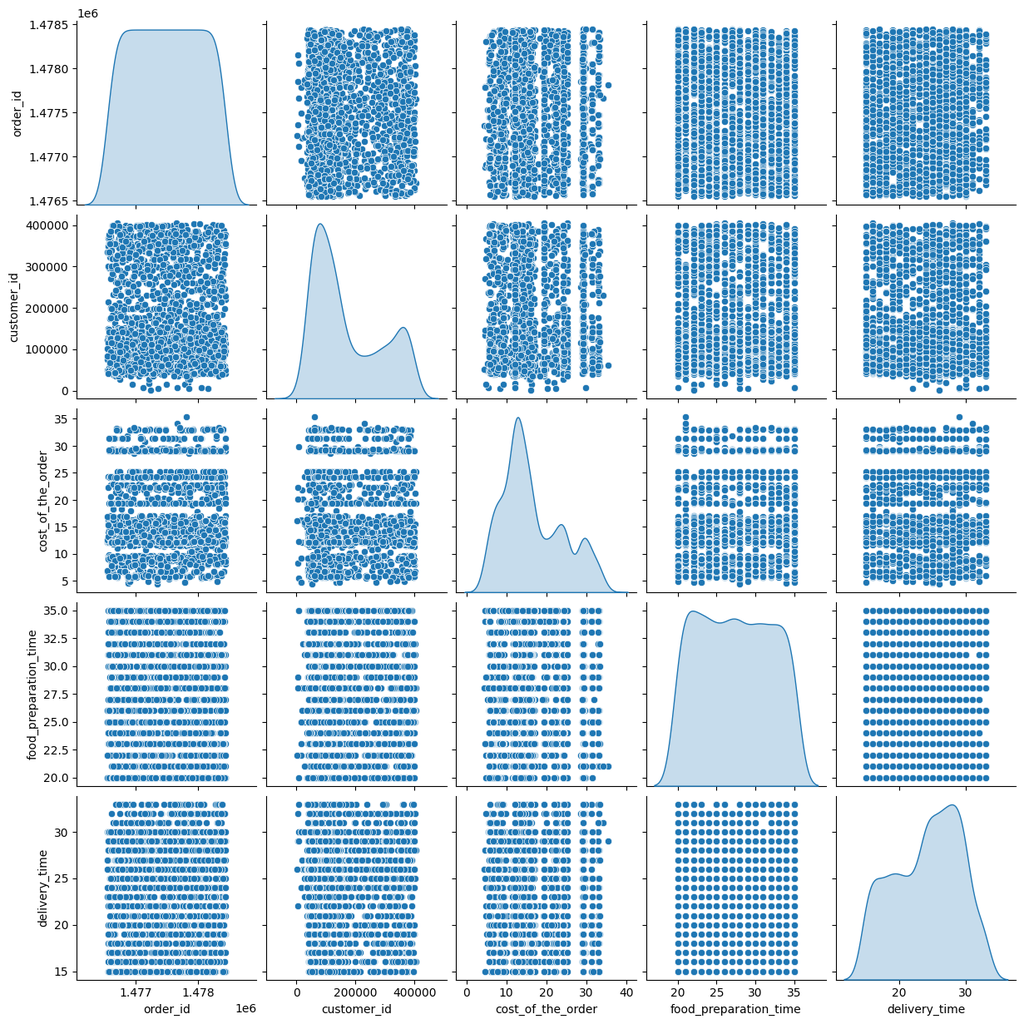

```python
# Display the relationship of numerical columns (order_id, customer_id, cost_of_the_order, food_preparation_time, delivery_time)
data = df[num_cols]

ax = sns.pairplot(data = data, diag_kind = 'kde')

plt.show()
```

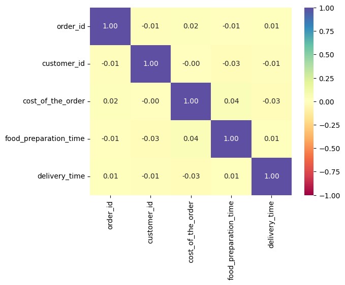

```python
# Display the relationship of numerical columns (order_id, customer_id, cost_of_the_order, food_preparation_time, delivery_time)
data = df[num_cols].corr()

ax = sns.heatmap(data = data, annot = True, vmin = -1, vmax = 1, fmt = '.2f', cmap = 'Spectral')

plt.xticks(rotation = 90)
plt.yticks(rotation = 0)
plt.show()
```

**Observations:**

- There are no numeric variables that show a relationship.
- There are no numeric variables that show a positive or negative correlation.

##### Observations on Cost of the Order:

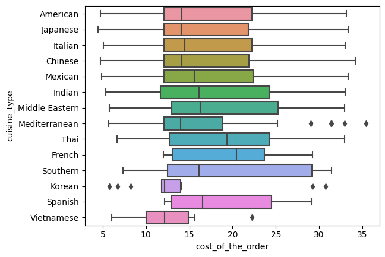

```python
# Display the distribution of cost_of_the_order per cuisine_type
data = df
order = data['cuisine_type'].value_counts().index

ax = sns.boxplot(data = data, x = 'cost_of_the_order', y = 'cuisine_type', order = order)

plt.show()
```

**Observations:**

- There are outliers found in the Cost of the Order for the Mediterranean, Korean and Vietnamese cuisines.

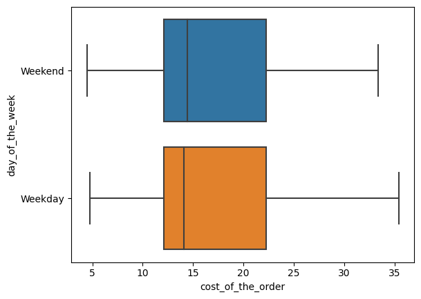

```python
# Display the distribution of cost_of_the_order per day_of_the_week
data = df
order = data['day_of_the_week'].value_counts().index

ax = sns.boxplot(data = data, x = 'cost_of_the_order', y = 'day_of_the_week', order = order)

plt.show()
```

**Observations:**

- There are no outliers found in the Cost of the Order irrespective if it is weekday or weekend.

##### Observations on Food Preparation Time:

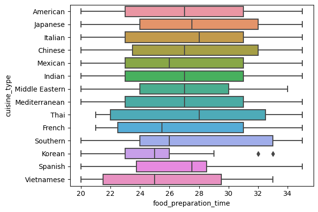

```python
# Display the distribution of food_preparation_time per cuisine_type
data = df
order = data['cuisine_type'].value_counts().index

ax = sns.boxplot(data = data, x = 'food_preparation_time', y = 'cuisine_type', order = order)

plt.show()
```

**Observations:**

- There are outliers found in the Food Preparation Time for the Korean cuisine.

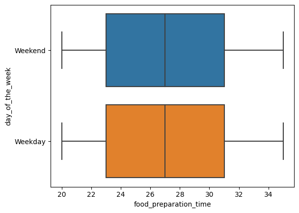

```python
# Display the distribution of food_preparation_time per day_of_the_week
data = df
order = data['day_of_the_week'].value_counts().index

ax = sns.boxplot(data = data, x = 'food_preparation_time', y = 'day_of_the_week', order = order)

plt.show()
```

**Observations:**

- There are no outliers found in the Food Preparation Time irrespective if it is weekday or weekend.

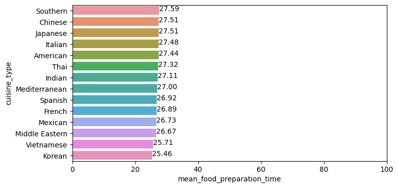

```python
# Display the average food_preparation_time of orders per cuisine_type
data = df.groupby(by = 'cuisine_type')['food_preparation_time'].mean().reset_index().rename(columns = {'food_preparation_time': 'mean_food_preparation_time'})
order = data.sort_values(by = 'mean_food_preparation_time', ascending = False)['cuisine_type']

plt.figure(figsize = (8, 4))

ax = sns.barplot(data = data, y = 'cuisine_type', x = 'mean_food_preparation_time', order = order)

set_bin_label_ybarplot(ax, data, '.2f')

plt.xlim(0, 100)
plt.show()
```

**Observations:**

- Southern cuisine takes the longest preparation time in FoodHub.
- List is followed by:
  - Chinese
  - Japanese
  - Italian
  - American

##### Observations on Delivery Time:

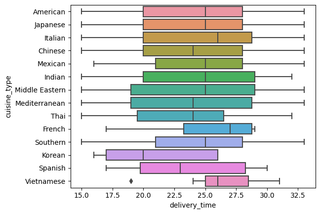

```python
# Display the distribution of delivery_time per cuisine_type
data = df
order = data['cuisine_type'].value_counts().index

ax = sns.boxplot(data = data, x = 'delivery_time', y = 'cuisine_type', order = order)

plt.show()
```

**Observations:**

- There are outliers found in the Delivery Time for the Vietnamese cuisine.

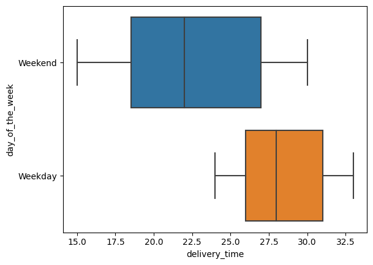

```python
# Display the distribution of delivery_time per day_of_the_week
data = df
order = data['day_of_the_week'].value_counts().index

ax = sns.boxplot(data = data, x = 'delivery_time', y = 'day_of_the_week', order = order)

plt.show()
```

**Observations:**

- There are no outliers found in the Delivery Time irrespective if it is weekday or weekend.

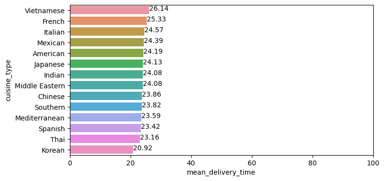

```python
# Display the average delivery_time of orders per cuisine_type
data = df.groupby(by = 'cuisine_type')['delivery_time'].mean().reset_index().rename(columns = {'delivery_time': 'mean_delivery_time'})
order = data.sort_values(by = 'mean_delivery_time', ascending = False)['cuisine_type']

plt.figure(figsize = (8, 4))

ax = sns.barplot(data = data, y = 'cuisine_type', x = 'mean_delivery_time', order = order)

set_bin_label_ybarplot(ax, data, '.2f')

plt.xlim(0, 100)
plt.show()
```

**Observations:**

- Vietnamese cuisine takes the longest delivery time in FoodHub.
- List is followed by:
  - French
  - Italian
  - Mexican
  - American

##### Observations on Cuisine Type:

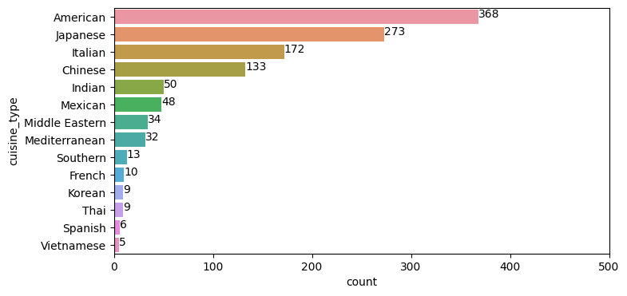

```python
# Display the number of orders per cuisine_type (only for orders that have been rated)
data = df_wth_rating.groupby(by = 'cuisine_type')['rating'].size().reset_index().rename(columns = {'rating': 'count'})
order = data.sort_values(by = 'count', ascending = False)['cuisine_type']

plt.figure(figsize = (8, 4))

ax = sns.barplot(data = data, y = 'cuisine_type', x = 'count', order = order)

set_bin_label_ybarplot(ax, data, '.0f')

plt.xlim(0, 500)
plt.show()
```

**Observations:**

- American cuisine is also the most rated cuisine in FoodHub. List is followed by:
  - Japanese
  - Italian
  - Chinese
  - Indian

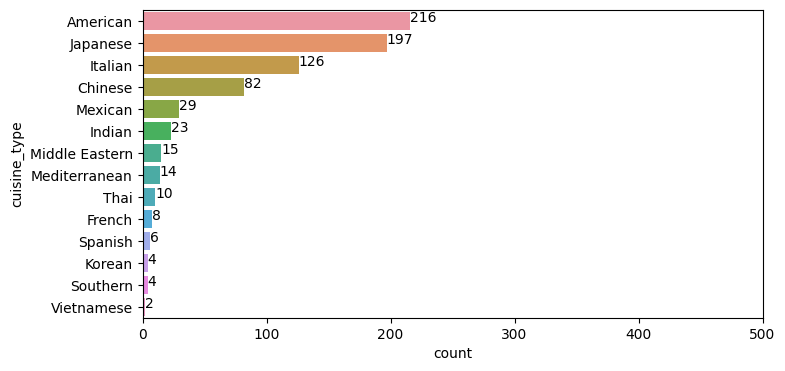

```python
# Display the number of orders per cuisine_type (only for orders that have not been rated)
data = df_wo_rating.groupby(by = 'cuisine_type')['rating'].size().reset_index().rename(columns = {'rating': 'count'})
order = data.sort_values(by = 'count', ascending = False)['cuisine_type']

plt.figure(figsize = (8, 4))

ax = sns.barplot(data = data, y = 'cuisine_type', x = 'count', order = order)

set_bin_label_ybarplot(ax, data, '.0f')

plt.xlim(0, 500)
plt.show()
```

**Observations:**

- American cuisine is also the most unrated cuisine in FoodHub. List is followed by:
  - Japanese
  - Italian
  - Chinese
  - Mexican

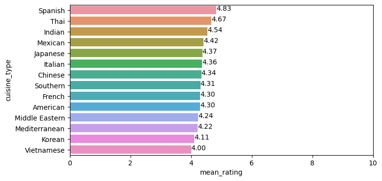

```python
# Display the average rating of orders per cuisine_type
data = df_wth_rating.groupby(by = 'cuisine_type')['rating'].mean().reset_index().rename(columns = {'rating': 'mean_rating'})
order = data.sort_values(by = 'mean_rating', ascending = False)['cuisine_type']

plt.figure(figsize = (8, 4))

ax = sns.barplot(data = data, y = 'cuisine_type', x = 'mean_rating', order = order)

set_bin_label_ybarplot(ax, data, '.2f')

plt.xlim(0, 10)
plt.show()
```

**Observations:**

- Spanish cuisine is the most highly rated cuisine in FoodHub. List is followed by:
  - Thai
  - Indian
  - Mexican
  - Japanese

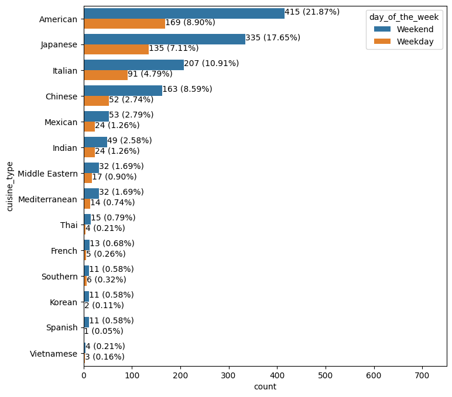

```python
# Display the number of orders per cuisine_type for each day_of_the_week
data = df
order = data['cuisine_type'].value_counts().index
hue_order = data['day_of_the_week'].value_counts().index

plt.figure(figsize = (8, 8))

ax = sns.countplot(data = data, y = 'cuisine_type', hue = 'day_of_the_week', order = order, hue_order = hue_order)

set_bin_label_ycountplot(ax, data, '.0f', '.2f')

plt.xlim(0, 750)
plt.show()
```

**Observations:**

- American cuisine is the most ordered cuisine in FoodHub irrespective if it's weekday or weekend. List is followed by:
  - Japanese
  - Italian
  - Chinese
  - Mexican
- It shows consistent popularity in the cuisines irrespective if it's weekday or weekend.

### **Question 13:** The company wants to provide a promotional offer in the advertisement of the restaurants. The condition to get the offer is that the restaurants must have a rating count of more than 50 and the average rating should be greater than 4. Find the restaurants fulfilling the criteria to get the promotional offer.

```python
# Display the restaurants that have rating count more than 50 and average rating more than 4
res_promo_offer = df_wth_rating.groupby(by = ['cuisine_type', 'restaurant_name']).agg(count = ('rating', 'size'), mean = ('rating', 'mean')).loc[lambda agg: (agg['count'] > 50) & (agg['mean'] > 4)].sort_values(by = 'mean', ascending = False).reset_index()

res_promo_offer
```

|  | cuisine_type | restaurant_name | count | mean |
| --- | --- | --- | --- | --- |
| 0 | Italian | The Meatball Shop | 70 | 4.528571 |
| 1 | American | Blue Ribbon Fried Chicken | 64 | 4.328125 |
| 2 | American | Shake Shack | 133 | 4.278195 |
| 3 | Japanese | Blue Ribbon Sushi | 73 | 4.219178 |

**Observations:**

- Blue Ribbon Fried Chicken (64 and 4.33) and Shake Shack (133 and 4.28) restaurants are both American cuisines that qualifies for the promotion offer. This shows the poularity of American cuisines in New York.
- List also includes: The Meatball Shop (70 and 4.53) and Blue Ribbon Sushi (73 and 4.22) restaurants.

### **Question 14:** The company charges the restaurant 25% on the orders having cost greater than 20 dollars and 15% on the orders having cost greater than 5 dollars. Find the net revenue generated by the company across all orders.

```python
# Display the total revenue from all orders
df.loc[(df['cost_of_the_order'] > 5) & (df['cost_of_the_order'] <= 20), 'revenue'] = df['cost_of_the_order'] * 0.15
df.loc[df['cost_of_the_order'] > 20, 'revenue'] = df['cost_of_the_order'] * 0.25
df.loc[df['cost_of_the_order'] <= 5, 'revenue'] = 0

df['revenue'] = df['revenue'].astype(float)

df['revenue'].sum()
```

```
6166.303
```

**Observations:**

- The net revenue of FoodHub for all orders is 6,166.303 dollars.

### **Question 15:** The company wants to analyze the total time required to deliver the food. What percentage of orders take more than 60 minutes to get delivered from the time the order is placed? (The food has to be prepared and then delivered.)

```python
# Display the percentage of orders that take more or less than 60 minutes to get delivered
greater_60_turnover_pct = df.apply(lambda df: True if df['overall_order_time'] > 60 else False, axis = 1).value_counts(normalize = True).mul(100).reset_index().rename(columns = {'index': 'is_overall_order_time_greater_60', 0: 'percentage'})

greater_60_turnover_pct
```

|  | is_overall_order_time_greater_60 | percentage |
| --- | --- | --- |
| 0 | False | 89.462592 |
| 1 | True | 10.537408 |

```python
# Display the percentage of orders that take more than 60 minutes to get delivered
greater_60_turnover_pct[greater_60_turnover_pct['is_overall_order_time_greater_60'] == True]
```

|  | is_overall_order_time_greater_60 | percentage |
| --- | --- | --- |
| 1 | True | 10.537408 |

**Observations:**

- 10.54% of the orders take more than 60 minutes to get prepared and delivered to the customers.
- While 89.46% of the orders take less than or equal to 60 minutes to get prepared and delivered.

### **Question 16:** The company wants to analyze the delivery time of the orders on weekdays and weekends. How does the mean delivery time vary during weekdays and weekends?

```python
# Display the average delivery time of orders per day_of_the_week
del_time_mean = df.groupby(by = 'day_of_the_week')['delivery_time'].mean().reset_index().rename(columns = {'delivery_time': 'mean'})

del_time_mean
```

|  | day_of_the_week | mean |
| --- | --- | --- |
| 0 | Weekday | 28.340037 |
| 1 | Weekend | 22.470022 |

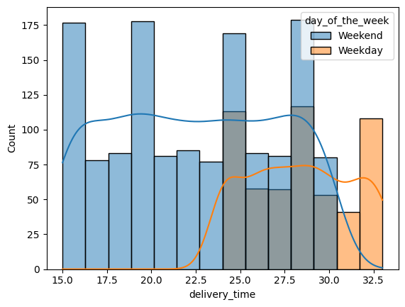

```python
# Display the distribution of delivery_time per day_of_the_week
data = df
hue_order = data['day_of_the_week'].value_counts().index

sns.histplot(data = data, x = 'delivery_time', hue = 'day_of_the_week', kde = True, hue_order = hue_order)

plt.show()
```

**Observations:**

- The average delivery time on weekdays is greater than the average delivery time on weekends. This may be due to worse traffic conditions on weekdays than on weekends.